[figure not shown]

# **HOUSING PRICES, LANDMARKS AND PLACES OF INTEREST**

Relationship between cost of housing and amenities of a suburb

**Authored by: Yash K Daware and Vaibhavi J Deo**

**Duration:** 90 mins

**Level:** {Intermediate}

**Pre-requisite Skills:** Python, Numpy, Pandas, Seaborn, Plotly, Folium

Scenario

**Scenario 1: New Home Buyer's Perspective**

As a prospective homebuyer in Suburb X, understanding the factors influencing property prices is crucial. By analyzing amenities like hospitals, places of worship, and shopping centers, along with property prices, buyers can make informed decisions. Data analysis reveals that Suburb X's higher property prices are linked to its quality amenities. This insight will help buyers assess the value of properties in the area.

**Scenario 2: Builder's Perspective**

Builders planning projects in Suburb Y analyze market dynamics and amenities' impact on property demand. By studying recent sales and amenities like hospitals and shopping centers, builders identify prime locations for development. Insights gained help tailor projects to meet buyer preferences, maximizing success and profitability.

**Scenario 3: Council's Perspective**

Local councils overseeing Suburb Z can use an analysis like this to enhance its appeal and livability. Through data analysis and stakeholder engagement, council can assess existing amenities and identify areas for improvement. Strategic initiatives, such as infrastructure investments and public-private partnerships, boost Suburb Z's attractiveness and stimulate economic development.

In this usecase we intend to understand what impact does the amenities of a suburb such as hospitals, places of worship, shopping centres, tourist attractions have on the housing market of the suburb.

For the usecase, we will be doing correlation analysis and regression analysis, I will begin by analyzing property data to explore how prices vary across different suburbs. Next, I will examine the number and Types of landmarks present in each area to determine if their presence correlates with variations in median property prices.

The primary objective is to investigate whether the quantity and nature of landmarks have an impact on property prices. By conducting this analysis, I aim to identify which Types of landmarks, if any, significantly influence property prices. This initial investigation will provide insights into the relationship between landmarks and property values within the studied suburb.

This can help home buyers in understanding how the property prices are driven by the landmarks present in the suburb of their choice, can help real estate agents to do market segmentation and be able to better serve their clients in their budgets and amenety preferences. Can also aid builders in projecting the outcomes of the projects in each area. Also shall help Councils to understand what measures to take to make the area more liveable and identifies areas of improvement.

# Importing Libraries

```python
!pip install geopandas
!pip install folium

import requests
import numpy as np
import pandas as pd

import plotly.express as px
import warnings
warnings.filterwarnings("ignore")

import requests
from io import StringIO

import matplotlib.pyplot as plt
import seaborn as sns
import geopandas as gpd
import folium
import plotly.graph_objects as go

from scipy.stats import zscore

from sklearn.linear_model import LogisticRegression
from sklearn.ensemble import RandomForestClassifier
from sklearn.metrics import accuracy_score, classification_report, confusion_matrix
```

[output not shown]

[output cut: 52 more lines]

[output not shown]

# Loading the [House Prices by Small Area](https://https://data.melbourne.vic.gov.au/explore/dataset/house-prices-by-small-area-sale-year/table/) Dataset

```python
def API_unlimited(datasetName):

    dataset_id = datasetName
    # https://data.melbourne.vic.gov.au/explore/dataset/pedestrian-counting-system-monthly-counts-per-hour/information/
    #dataset_id = 'pedestrian-counting-system-monthly-counts-per-hour'

    base_url = 'https://data.melbourne.vic.gov.au/api/explore/v2.1/catalog/datasets/'
    #apikey = api_key
    dataset_id = dataset_id
    format = 'csv'

    url = f'{base_url}{dataset_id}/exports/{format}'
    params = {
        'select': '*',
        'limit': -1,  # all records
        'lang': 'en',
        'timezone': 'UTC',
       # 'api_key': apikey
    }

    # GET request
    response = requests.get(url, params=params)

    if response.status_code == 200:
        # StringIO to read the CSV data
        url_content = response.content.decode('utf-8')
        datasetName = pd.read_csv(StringIO(url_content), delimiter=';')
        print(datasetName.sample(10, random_state=999)) # Test
        return datasetName
    else:
        print(f'Request failed with status code {response.status_code}')
```

```python
dataset_id_1 = 'house-prices-by-small-area-sale-year'

dataset1 = API_unlimited(dataset_id_1)
```

```
     sale_year       small_area                   type  median_price  \
272       2004  North Melbourne        House/Townhouse      370000.0
300       2008        Parkville        House/Townhouse      590000.0
198       2008      South Yarra        House/Townhouse     1917500.0
173       2004       Kensington        House/Townhouse      355000.0
159       2002  North Melbourne        House/Townhouse      351000.0
57        2007       Kensington  Residential Apartment      349000.0
288       2007          Carlton  Residential Apartment      395000.0
169       2003        Parkville        House/Townhouse      713500.0
247       2016        Docklands        House/Townhouse           NaN
167       2003  Melbourne (CBD)  Residential Apartment      298200.0

     transaction_count
272                110
300                 68
198                 30
173                194
159                148
57                 157
288                291
169                 32
247                  5
167               1367
```

```python
#house_price = pd.read_csv("https://data.melbourne.vic.gov.au/api/explore/v2.1/catalog/datasets/house-prices-by-small-area-sale-year/exports/csv?lang=en&timezone=Australia%2FSydney&use_labels=true&delimiter=%2C")
```

```python
house_price= dataset1
house_price.head(10)
```

|  | sale_year | small_area | type | median_price | transaction_count |
| --- | --- | --- | --- | --- | --- |
| 0 | 2000 | Carlton | House/Townhouse | 316250.0 | 116 |
| 1 | 2000 | Carlton | Residential Apartment | 220000.0 | 309 |
| 2 | 2000 | East Melbourne | House/Townhouse | 622500.0 | 42 |
| 3 | 2000 | East Melbourne | Residential Apartment | 295000.0 | 139 |
| 4 | 2000 | Kensington | House/Townhouse | 215250.0 | 258 |
| 5 | 2000 | Melbourne (CBD) | House/Townhouse | NaN | 3 |
| 6 | 2000 | Melbourne (CBD) | Residential Apartment | 276000.0 | 1065 |
| 7 | 2000 | Melbourne (Remainder) | Residential Apartment | 284500.0 | 57 |
| 8 | 2000 | North Melbourne | House/Townhouse | 280000.0 | 115 |
| 9 | 2000 | Parkville | Residential Apartment | 231300.0 | 168 |

**For the given Dataset we observe the shape and Data Type for each column To Know more about the data we are dealing with**

```python
# Displaying shape
print("Shape of the dataset:")
print(housing_data.shape)

# Displaying data Types
print("\nData Types of the dataset:")
print(housing_data.dtypes)
```

[output not shown]

**Cleaning the data by eliminating null values.**

```python
#Finding null and Zero values
null_values = housing_data.isnull().sum()

zero_values = (housing_data == 0).sum()

print("Null values:")
print(null_values)

print("\nZero values:")
print(zero_values)
```

```
Null values:
Sale_Year             0
Small_Area            7
Type                  0
Median_Price         28
Transaction_Count     0
dtype: int64

Zero values:
Sale_Year            0
Small_Area           0
Type                 0
Median_Price         5
Transaction_Count    0
dtype: int64
```

**Cleaning the House Prices dataset and displaying a cleaned version of the dataset.**

```python
# Dropping rows with NaN, 0, or NA values
housing_price = house_price.dropna(axis=0, how='any')
housing_price = housing_price.replace(0, pd.NA).dropna()
housing_price = housing_price[housing_price['Median_Price'] >= 100000].reset_index(drop=True)


print("Cleaned dataset shape:", housing_price.shape)
print("\n Cleaned data:")
housing_price
```

```
Cleaned dataset shape: (310, 5)

 Cleaned data:
```

|  | Sale_Year | Small_Area | Type | Median_Price | Transaction_Count |
| --- | --- | --- | --- | --- | --- |
| 0 | 2000 | Carlton | House/Townhouse | 316250.0 | 116 |
| 1 | 2000 | Carlton | Residential Apartment | 220000.0 | 309 |
| 2 | 2000 | East Melbourne | House/Townhouse | 622500.0 | 42 |
| 3 | 2000 | East Melbourne | Residential Apartment | 295000.0 | 139 |
| 4 | 2000 | Kensington | House/Townhouse | 215250.0 | 258 |
| ... | ... | ... | ... | ... | ... |
| 305 | 2016 | North Melbourne | Residential Apartment | 515000.0 | 231 |
| 306 | 2016 | Parkville | House/Townhouse | 1761250.0 | 32 |
| 307 | 2016 | Parkville | Residential Apartment | 500000.0 | 63 |
| 308 | 2016 | South Yarra | House/Townhouse | 2135000.0 | 34 |
| 309 | 2016 | Southbank | Residential Apartment | 565000.0 | 701 |

310 rows × 5 columns

**Cleaning the dataset by eliminating the extreme values that may skew the data.**

```python
import numpy as np

# Calculate the 1st and 99th percentiles of 'Median_Price'
price_1st_percentile = housing_price['Median_Price'].quantile(0.01)
price_99th_percentile = housing_price['Median_Price'].quantile(0.99)

# Filter out the extreme values based on percentiles
housing_price = housing_price[(housing_price['Median_Price'] <= price_99th_percentile)].reset_index(drop=True)


print("Cleaned dataset shape:", housing_price.shape)
print("\n Cleaned data:")
housing_price
```

```
Cleaned dataset shape: (306, 5)

 Cleaned data:
```

|  | Sale_Year | Small_Area | Type | Median_Price | Transaction_Count |
| --- | --- | --- | --- | --- | --- |
| 0 | 2000 | Carlton | House/Townhouse | 316250.0 | 116 |
| 1 | 2000 | Carlton | Residential Apartment | 220000.0 | 309 |
| 2 | 2000 | East Melbourne | House/Townhouse | 622500.0 | 42 |
| 3 | 2000 | East Melbourne | Residential Apartment | 295000.0 | 139 |
| 4 | 2000 | Kensington | House/Townhouse | 215250.0 | 258 |
| ... | ... | ... | ... | ... | ... |
| 301 | 2016 | North Melbourne | Residential Apartment | 515000.0 | 231 |
| 302 | 2016 | Parkville | House/Townhouse | 1761250.0 | 32 |
| 303 | 2016 | Parkville | Residential Apartment | 500000.0 | 63 |
| 304 | 2016 | South Yarra | House/Townhouse | 2135000.0 | 34 |
| 305 | 2016 | Southbank | Residential Apartment | 565000.0 | 701 |

306 rows × 5 columns

# Number of Transactions that took place each year

```python
import plotly.graph_objects as go

# Grouping the data
transaction_counts = housing_price.groupby('Sale_Year')['Transaction_Count'].sum()

# Calculating the average transaction count per year
average_transaction_count = transaction_counts.mean()

# Creating a bar plot
fig = go.Figure(data=[go.Bar(x=transaction_counts.index, y=transaction_counts.values)])

# Adding a horizontal line for the average transaction count
fig.add_shape(type='line',
              x0=min(transaction_counts.index), y0=average_transaction_count,
              x1=max(transaction_counts.index), y1=average_transaction_count,
              line=dict(color='red', width=2, dash='dash'),
              name=f'Average ({average_transaction_count:.2f} transactions/year)')

fig.update_layout(
    title='Number of Transactions Each Year',
    xaxis=dict(title='Year'),
    yaxis=dict(title='Transaction Count'),
)

fig.show()
```

[interactive chart not shown]

**From the above bar plot we can observe the trends of number of transactions over the years, we have also represented the average number of traansactions each year by a dotted red line. This helps us observe which years had an above average number of Housing transactions taking place. We can observe that the period between 2009 to 2014 we had an increase in the number of transactions as compared to the average. Later, we would observe if this was also true or not for each suburb.**

# Listing The Suburbs in the Dataset

**Finding out the suburbs for which we have the Housing prices data in the House Prices by Small Area dataset.**

```python
# Listing the Suburbs
unique_Small_Areas = housing_price['Small_Area'].unique()

print("Separate elements:")
for area in unique_Small_Areas:
    print(area)
```

```
Separate elements:
Carlton
East Melbourne
Kensington
Melbourne (CBD)
Melbourne (Remainder)
North Melbourne
Parkville
South Yarra
West Melbourne (Residential)
Southbank
Docklands
```

# Grouping data from the same suburbs together

```python
suburb_groups = housing_price.groupby('Small_Area')
suburb_datasets = {}  # Initialize an empty dictionary to store datasets for each suburb

for suburb, data in suburb_groups:
    suburb_datasets[suburb] = data.copy()  # Store the dataset for the current suburb in the dictionary

# Now suburb_datasets is a dictionary where each key is a suburb name and each value is the corresponding dataset.

suburb_datasets['Docklands']
```

|  | Sale_Year | Small_Area | Type | Median_Price | Transaction_Count |
| --- | --- | --- | --- | --- | --- |
| 51 | 2007 | Docklands | Residential Apartment | 565000.0 | 653 |
| 76 | 2010 | Docklands | House/Townhouse | 1450000.0 | 57 |
| 77 | 2010 | Docklands | Residential Apartment | 610000.0 | 851 |
| 85 | 2011 | Docklands | Residential Apartment | 604450.0 | 772 |
| 95 | 2012 | Docklands | House/Townhouse | 1900000.0 | 12 |
| 111 | 2014 | Docklands | House/Townhouse | 895000.0 | 12 |
| 112 | 2014 | Docklands | Residential Apartment | 580000.0 | 1098 |
| 119 | 2015 | Docklands | House/Townhouse | 1880000.0 | 11 |
| 120 | 2015 | Docklands | Residential Apartment | 576500.0 | 608 |
| 132 | 2016 | Docklands | Residential Apartment | 591000.0 | 371 |
| 137 | 2000 | Docklands | Residential Apartment | 487300.0 | 556 |
| 160 | 2004 | Docklands | Residential Apartment | 445000.0 | 252 |
| 201 | 2012 | Docklands | Residential Apartment | 580000.0 | 590 |
| 206 | 2013 | Docklands | Residential Apartment | 619500.0 | 800 |
| 233 | 2001 | Docklands | Residential Apartment | 525375.0 | 766 |
| 238 | 2002 | Docklands | Residential Apartment | 502000.0 | 755 |
| 249 | 2005 | Docklands | Residential Apartment | 480000.0 | 250 |
| 254 | 2006 | Docklands | Residential Apartment | 535450.0 | 427 |
| 263 | 2007 | Docklands | House/Townhouse | 1532000.0 | 32 |
| 268 | 2008 | Docklands | Residential Apartment | 502000.0 | 654 |
| 273 | 2009 | Docklands | Residential Apartment | 541000.0 | 779 |

# Plotting Median Price of Houses from all the Suburbs with respect to the year in which the House was sold.

```python
import plotly.graph_objects as go
import numpy as np

for suburb_name in unique_Small_Areas:
    dataset = suburb_datasets[suburb_name].sort_values(by='Sale_Year')

    # Create figure
    fig = go.Figure()

    # Add bar trace for Median_Price against Sale_Year with custom color
    fig.add_trace(go.Bar(x=dataset['Sale_Year'],
                         y=dataset['Median_Price'],
                         marker=dict(color='rgb(135, 16, 100)')))  # Custom color

    # Update layout
    fig.update_layout(title=f'Housing Price in {suburb_name} Over the Years',
                      xaxis_title='Sale Year',
                      yaxis_title='Median Price',
                      xaxis=dict(tickmode='linear'),
                      yaxis=dict(tickformat='$,'))

    # Show interactive plot
    fig.show()
```

[interactive chart not shown]

# Median Price of Houses in each Suburb

```python
# Create an empty dictionary to store median of median prices for each suburb
median_of_suburbs = {}

# Iterate over each suburb in the unique_Small_Areas list
for suburb_name in unique_Small_Areas:
    # Select the dataset for the current suburb and sort it by 'Sale_Year'
    dataset = suburb_datasets[suburb_name].sort_values(by='Sale_Year')

    # Calculate the median of the 'Median_Price' column for the current suburb
    sub_Median_Price = np.median(dataset['Median_Price'])

    # Store the result in the dictionary with suburb name as key
    median_of_suburbs[suburb_name] = sub_Median_Price

# Print the median of median prices for each suburb
for suburb_name, median in median_of_suburbs.items():
    print(f" Median Price of Housing in {suburb_name}: {median}")
```

```
 Median Price of Housing in Carlton: 452500.0
 Median Price of Housing in East Melbourne: 663750.0
 Median Price of Housing in Kensington: 415000.0
 Median Price of Housing in Melbourne (CBD): 378000.0
 Median Price of Housing in Melbourne (Remainder): 500000.0
 Median Price of Housing in North Melbourne: 431125.0
 Median Price of Housing in Parkville: 516000.0
 Median Price of Housing in South Yarra: 651000.0
 Median Price of Housing in West Melbourne (Residential): 454500.0
 Median Price of Housing in Southbank: 494400.0
 Median Price of Housing in Docklands: 580000.0
```

# Median Price of Housing in each Suburb

```python
import plotly.graph_objects as go
Median_Price_df = pd.DataFrame({'Suburb': list(median_of_suburbs.keys()),
                                'Median_Price': list(median_of_suburbs.values())})
# Sort the DataFrame by Median_Price
Median_Price_df = Median_Price_df.sort_values(by='Median_Price')

# Create an interactive line chart with markers
fig = go.Figure()

fig.add_trace(go.Scatter(x=Median_Price_df['Suburb'],
                         y=Median_Price_df['Median_Price'],
                         mode='lines+markers'))

# Update layout
fig.update_layout(title='Median Price of Housing in each Suburb',
                  xaxis_title='Suburb',
                  yaxis_title='Median Price',
                  xaxis=dict(tickangle=45),
                  yaxis=dict(tickformat='$,.0f'),
                  plot_bgcolor='lightgrey')

# Show interactive plot
fig.show()
```

[interactive chart not shown]

```python
# Create an empty dictionary to store median of median prices for each suburb
mean_of_suburbs = {}

# Iterate over each suburb in the unique_Small_Areas list
for suburb_name in unique_Small_Areas:
    # Select the dataset for the current suburb and sort it by 'Sale_Year'
    dataset = suburb_datasets[suburb_name].sort_values(by='Sale_Year')

    # Calculate the median of the 'Median_Price' column for the current suburb
    sub_mean_price = np.mean(dataset['Median_Price'])

    # Store the result in the dictionary with suburb name as key
    mean_of_suburbs[suburb_name] = sub_mean_price
```

```python
import plotly.graph_objects as go
mean_price_df = pd.DataFrame({'Suburb': list(mean_of_suburbs.keys()),
                                'Mean_Price': list(mean_of_suburbs.values())})
# Sort the DataFrame by Median_Price
mean_price_df = mean_price_df.sort_values(by='Mean_Price')

# Create an interactive line chart with markers
fig = go.Figure()

fig.add_trace(go.Scatter(x=mean_price_df['Suburb'],
                         y=mean_price_df['Mean_Price'],
                         mode='lines+markers'))

# Update layout
fig.update_layout(title='Mean Price of Housing in each Suburb',
                  xaxis_title='Suburb',
                  yaxis_title='Mean Price',
                  xaxis=dict(tickangle=45),
                  yaxis=dict(tickformat='$,.0f'),
                  plot_bgcolor='lightgrey')

# Show interactive plot
```

[interactive chart not shown]

# Number of Property Transactions in each suburb over the years

**In the following section we obsereve the trend of number of property transactions in each suburb, for every suburb we have highlighted the average number of transactions by a dotted red line.**

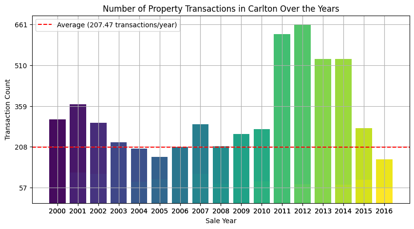

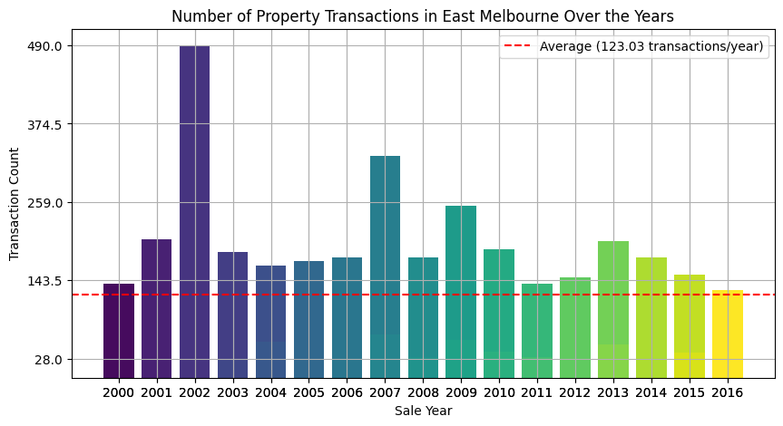

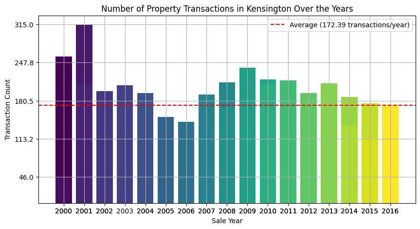

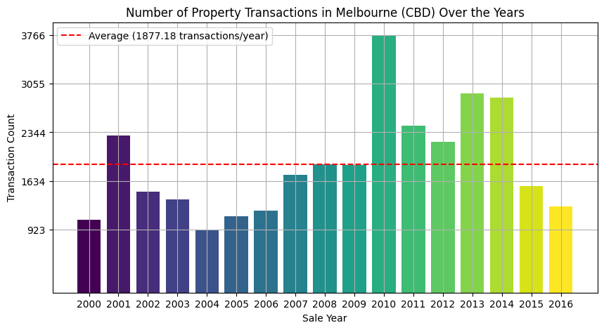

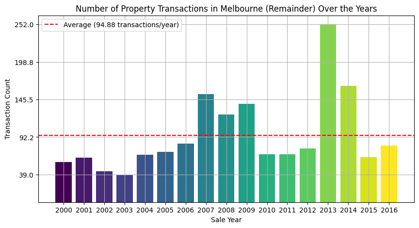

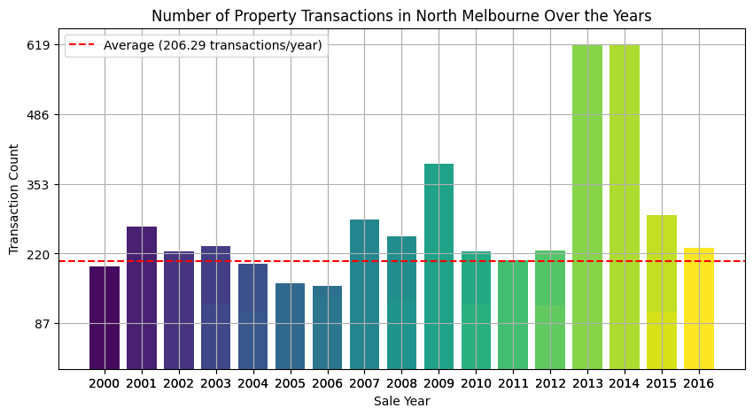

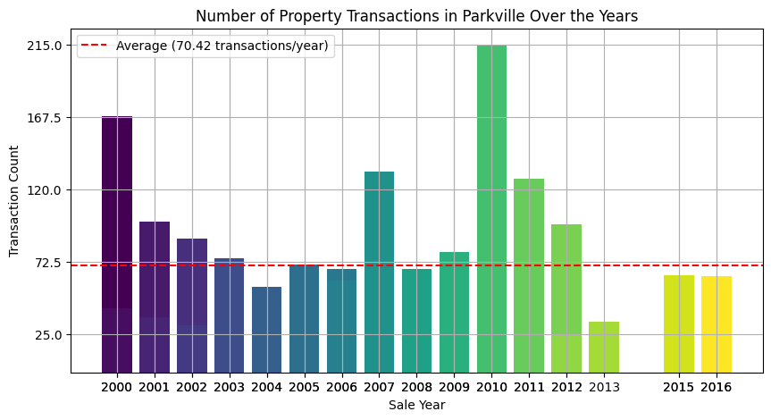

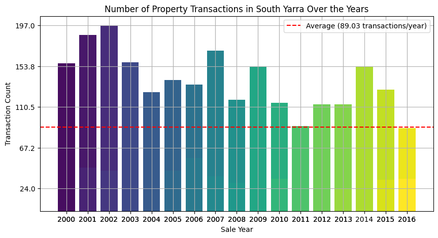

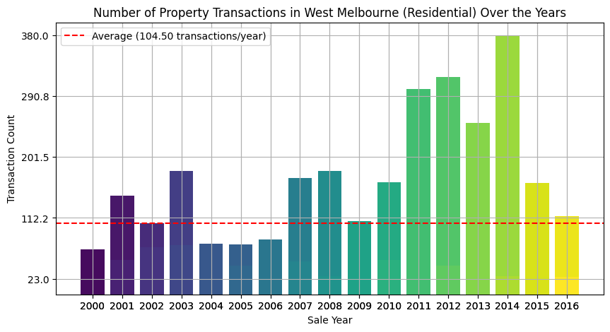

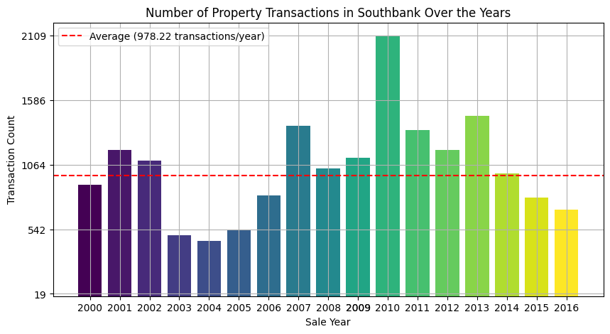

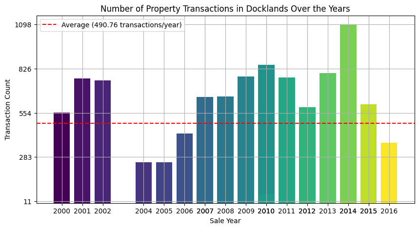

```python
for suburb_name in unique_Small_Areas:
    # Selecting dataset for the current suburb and sort it by 'Sale_Year'
    dataset = suburb_datasets[suburb_name].sort_values(by='Sale_Year')

    plt.figure(figsize=(10, 5))

    # Plotting Transaction_Count against Sale_Year
    plt.bar(dataset['Sale_Year'], dataset['Transaction_Count'],  color=plt.cm.viridis(np.linspace(0, 1, len(dataset))))

    # Calculating the average transaction count for the current suburb
    average_transaction_count = dataset['Transaction_Count'].mean()

    # Adding a horizontal line for the average transaction count
    plt.axhline(y=average_transaction_count, color='r', linestyle='--', label=f'Average ({average_transaction_count:.2f} transactions/year)')

    plt.title(f'Number of Property Transactions in {suburb_name} Over the Years')
    plt.xlabel('Sale Year')
    plt.ylabel('Transaction Count')
    plt.grid(True)
    plt.xticks(dataset['Sale_Year'])

    Transaction_Count = dataset['Transaction_Count']
    plt.yticks(np.linspace(Transaction_Count.min(), Transaction_Count.max(), 5))

    plt.legend()
    plt.show()
```

# Average number of transacions for each Suburb

```python
mean_transaction = {}

# Iterating over each suburb in the unique_Small_Areas list
for suburb_name in unique_Small_Areas:

    dataset = suburb_datasets[suburb_name].sort_values(by='Sale_Year')

    # Calculating the mean of the 'Transaction_Count' column for each suburb
    sub_mean_transaction = np.mean(dataset['Transaction_Count'])

    mean_transaction [suburb_name] = sub_mean_transaction

# Displaying the median of median prices for each suburb
for suburb_name, mean in mean_transaction.items():
    print(f" Average number of transacions in {suburb_name}: {mean:.2f}")
```

```
 Average number of transacions in Carlton: 207.47
 Average number of transacions in East Melbourne: 123.03
 Average number of transacions in Kensington: 172.39
 Average number of transacions in Melbourne (CBD): 1877.18
 Average number of transacions in Melbourne (Remainder): 94.88
 Average number of transacions in North Melbourne: 206.29
 Average number of transacions in Parkville: 70.42
 Average number of transacions in South Yarra: 89.03
 Average number of transacions in West Melbourne (Residential): 104.50
 Average number of transacions in Southbank: 978.22
 Average number of transacions in Docklands: 490.76
```

# Average Number of Property Transactions in Each Suburb

```
WARNING:matplotlib.legend:No artists with labels found to put in legend.  Note that artists whose label start with an underscore are ignored when legend() is called with no argument.
```

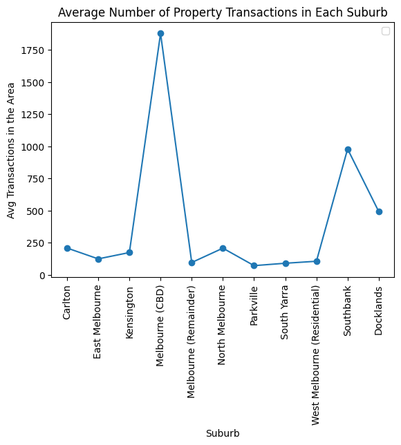

```python
mean_transaction_df = pd.DataFrame({'Suburb': list(mean_transaction.keys()),
                                'Transaction_Count': list(mean_transaction.values())})

# Plotting the Avg Number of Transactions in a Suburb

plt.scatter(mean_transaction_df['Suburb'], mean_transaction_df['Transaction_Count'])
plt.plot(mean_transaction_df['Suburb'], mean_transaction_df['Transaction_Count'], linestyle='-')
plt.title('Average Number of Property Transactions in Each Suburb')
plt.xlabel('Suburb')
plt.ylabel('Avg Transactions in the Area')
plt.xticks(rotation=90)
plt.legend()
plt.show()
```

# Median House Prices in each Suburb over the years

The following part shows us the trends of the Median Property prices over the years for each suburb.

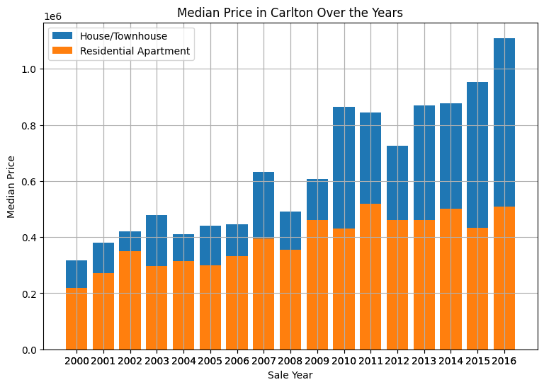

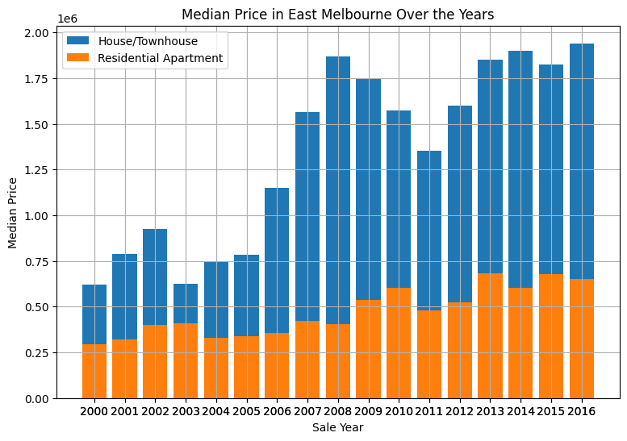

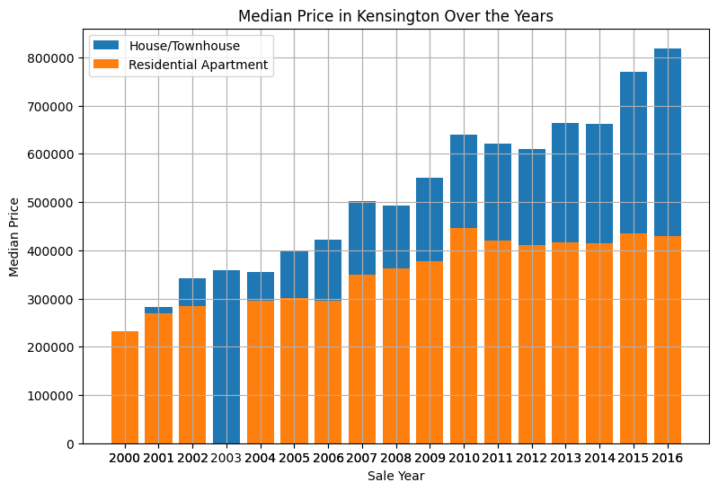

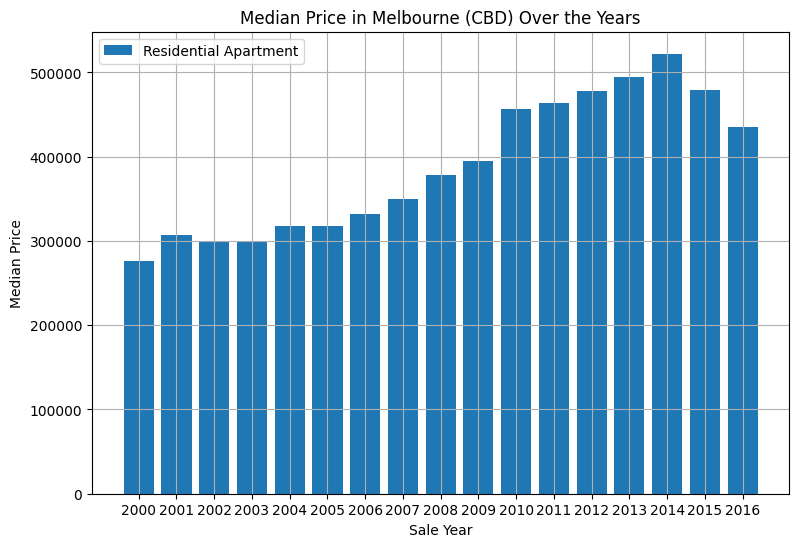

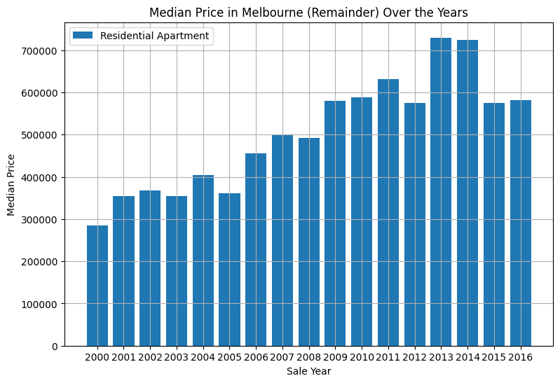

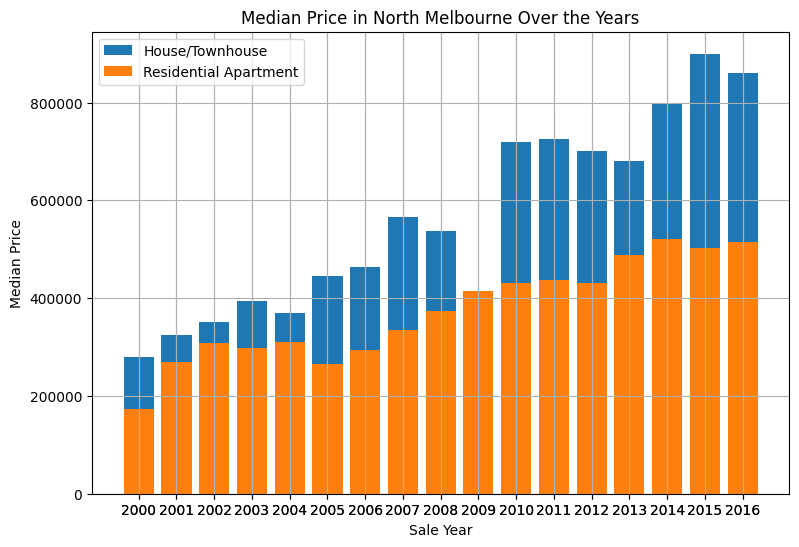

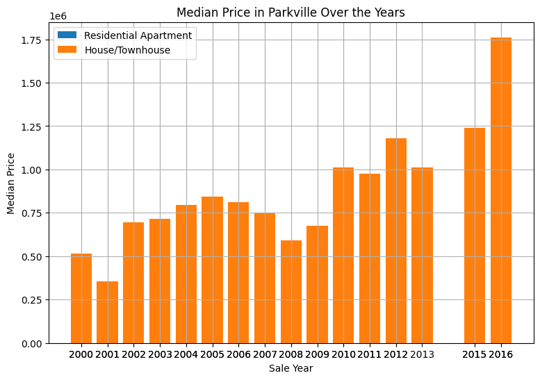

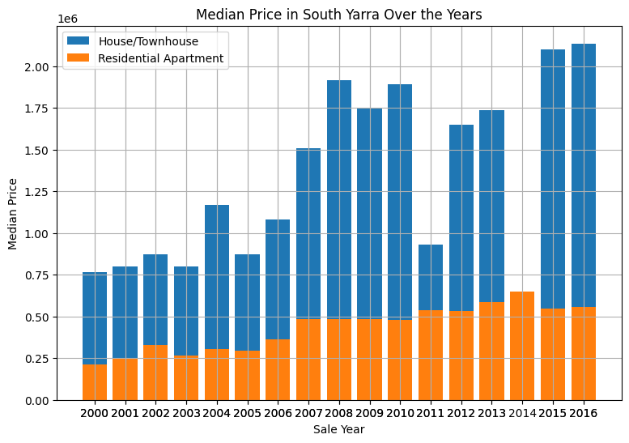

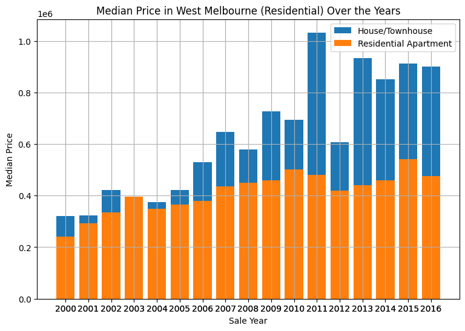

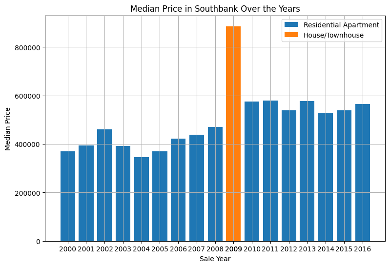

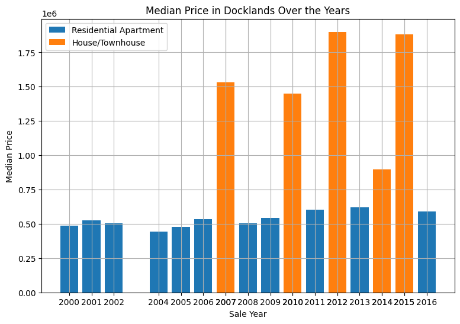

```python
for suburb_name in unique_Small_Areas:

    dataset = suburb_datasets[suburb_name].sort_values(by='Sale_Year')

    plt.figure(figsize=(9, 6))

    house_Types = dataset['Type'].unique()

    bottom_values = np.zeros(len(dataset))

    # Plotting each house Type
    for i, house_Type in enumerate(house_Types):

        house_data = dataset[dataset['Type'] == house_Type]


        plt.bar(house_data['Sale_Year'], house_data['Median_Price'], label= house_Type)



    plt.title(f'Median Price in {suburb_name} Over the Years')
    plt.xlabel('Sale Year')
    plt.ylabel('Median Price')
    plt.grid(True)
    plt.xticks(dataset['Sale_Year'])


    plt.legend()


    plt.show()
```

```python
from sklearn.linear_model import LinearRegression
regression_models = {}

# Iterating
for suburb, data in suburb_datasets.items():
    # Extract features (X) and target variable (y)
    X = data[['Sale_Year', 'Transaction_Count']]
    y = data['Median_Price']
    model = LinearRegression()
    model.fit(X, y)
    regression_models[suburb] = model
```